# Penguin

PROJET D: LES PENGUINS Dans ce scénario, nous cherchons à prédire l'espèce de manchots en fonction de deux mesures corporelles : la longueur du bec (culmen length) et la profondeur du bec (culmen depth). Explorons les concepts de features (caractéristiques) et de target (cible) : Les features (caractéristiques) : Les features sont les variables d'entrée utilisées pour faire des prédictions. Dans ce cas, les features sont :

Culmen length (longueur du bec) : une mesure numérique continue.

Culmen depth (profondeur du bec) : une autre mesure numérique continue. La target (cible) : La target est la variable que nous cherchons à prédire. Ici, la target est :

Penguin species (espèce de manchot) : une variable catégorielle qui indique l'espèce du manchot (par exemple, Adelie, Gentoo, Chinstrap).

En résumé : Features : culmen length, culmen depth (mesures numériques).

Target : penguin species (variable catégorielle).

L'objectif est d'utiliser les mesures du bec (features) pour prédire l'espèce du manchot (target). Cela relève d'un problème de classification, car la target est une variable catégorielle avec plusieurs classes possibles.

```python
df=pd.read_csv("./penguins_classification.csv")
```

```python
!jupyter nbconvert --to html Penguin.ipynb
```

```
[NbConvertApp] Converting notebook Penguin.ipynb to html
[NbConvertApp] WARNING | Alternative text is missing on 7 image(s).
[NbConvertApp] Writing 1025418 bytes to Penguin.html
```

```python
df
```

|  | Culmen Length (mm) | Culmen Depth (mm) | Species |
| --- | --- | --- | --- |
| 0 | 39.1 | 18.7 | Adelie |
| 1 | 39.5 | 17.4 | Adelie |
| 2 | 40.3 | 18.0 | Adelie |
| 3 | 36.7 | 19.3 | Adelie |
| 4 | 39.3 | 20.6 | Adelie |
| ... | ... | ... | ... |
| 337 | 55.8 | 19.8 | Chinstrap |
| 338 | 43.5 | 18.1 | Chinstrap |
| 339 | 49.6 | 18.2 | Chinstrap |
| 340 | 50.8 | 19.0 | Chinstrap |
| 341 | 50.2 | 18.7 | Chinstrap |

342 rows × 3 columns

```python
df["Species"].value_counts()
```

```
Species
Adelie       151
Gentoo       123
Chinstrap     68
Name: count, dtype: int64
```

Pour visualiser la distribution des caractéristiques numériques

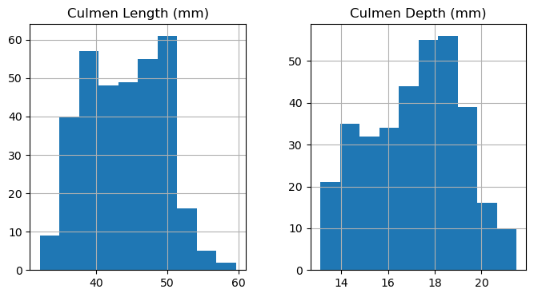

```python
_ = df.hist(figsize=(8, 4))
```

Afficher la distribution des caractéristiques pour chaque classe.

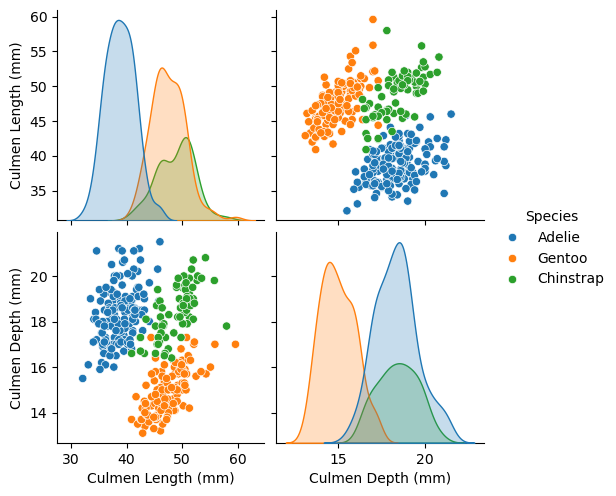

```python
# solution
import seaborn

pairplot_figure = seaborn.pairplot(df, hue="Species")
```

Interprétation Nous observons que les étiquettes sur les axes se chevauchent. Même si ce n'est pas la priorité de ce notebook, il est possible de les ajuster en augmentant la hauteur de chaque sous-figure.

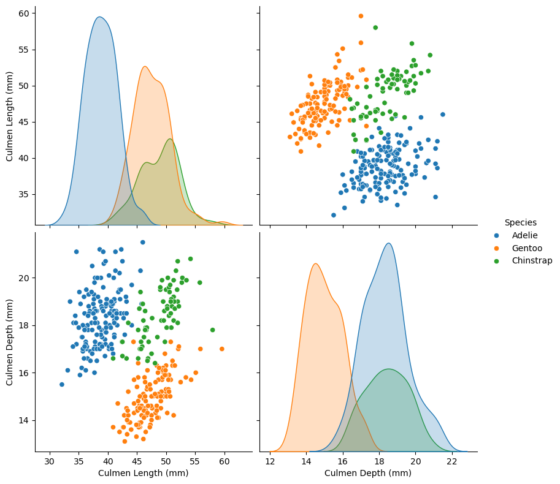

```python
pairplot_figure = seaborn.pairplot(df, hue="Species", height=4)
```

Commentaire En examinant ces distributions, à quel point pensez-vous qu'il serait difficile de classer les manchots en utilisant uniquement "culmen depth" (profondeur du bec) et "culmen length" (longueur du bec) ?

En regardant le scatter-plot précédent montrant "culmen length" et "culmen depth", les espèces sont raisonnablement bien séparées :

Longueur du bec faible -> Adelie

Profondeur du bec faible -> Gentoo

Profondeur du bec élevée et longueur du bec élevée -> Chinstrap

Il y a un léger chevauchement entre les espèces, donc nous pouvons nous attendre à ce qu'un modèle statistique performe bien sur ce dataset, mais pas parfaitement.

Construire un arbre de décision de classification Dans ce notebook, nous illustrons les arbres de décision dans un problème de classification multiclasse en utilisant le dataset des manchots avec 2 caractéristiques et 3 classes.

Pour simplifier, nous concentrons la discussion sur l'hyperparamètre max_depth, qui contrôle la profondeur maximale de l'arbre de décision.

Tout d'abord, nous divisons les données en deux sous-ensembles pour étudier comment les arbres prédisent des valeurs sur des données invisibles.

```python
from sklearn.model_selection import train_test_split

# Définir les colonnes des caractéristiques (features) et la cible (target)
culmen_columns = ["culmen_length_mm", "culmen_depth_mm"]  # Exemple de colonnes pour les caractéristiques
target_column = "species"  # Exemple de colonne pour la cible

# Séparer les données en caractéristiques (data) et cible (target)
data, target = df[culmen_columns], df[target_column]

# Diviser les données en ensembles d'entraînement et de test
data_train, data_test, target_train, target_test = train_test_split(
    data, target, random_state=0
)
```

[output not shown]

```python
print(df.columns)
```

```
Index(['Culmen Length (mm)', 'Culmen Depth (mm)', 'Species'], dtype='object')
```

```python
culmen_columns = ["Culmen Length (mm)", "Culmen Depth (mm)"]
target_column = "Species"
```

```python
from sklearn.model_selection import train_test_split

# Afficher les colonnes disponibles pour vérification
print("Colonnes disponibles :", df.columns)

# Définir les colonnes des caractéristiques (features) et la cible (target)
culmen_columns = ["Culmen Length (mm)", "Culmen Depth (mm)"]  # Noms corrigés
target_column = "Species"  # Nom corrigé

# Séparer les données en caractéristiques (data) et cible (target)
data, target = df[culmen_columns], df[target_column]

# Diviser les données en ensembles d'entraînement et de test
data_train, data_test, target_train, target_test = train_test_split(
    data, target, random_state=0
)
```

```
Colonnes disponibles : Index(['Culmen Length (mm)', 'Culmen Depth (mm)', 'Species'], dtype='object')
```

Dans un notebook précédent, nous avons appris que les classificateurs linéaires définissent une séparation linéaire pour diviser les classes en utilisant une combinaison linéaire des caractéristiques d'entrée. Dans notre espace de caractéristiques à 2 dimensions, cela signifie qu'un classificateur linéaire trouve les lignes obliques qui séparent le mieux les classes. Cela reste vrai pour les problèmes multiclasses, sauf que plus d'une ligne est ajustée. Nous pouvons utiliser DecisionBoundaryDisplay pour tracer les frontières de décision apprises par le classificateur.

```python
from sklearn.linear_model import LogisticRegression

linear_model = LogisticRegression()
linear_model.fit(data_train, target_train)
```

```
LogisticRegression()
```

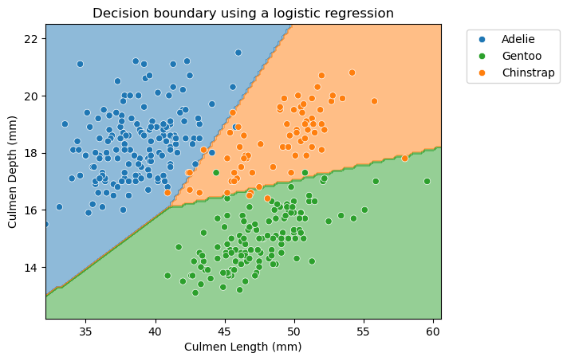

```python
import matplotlib.pyplot as plt
import matplotlib as mpl
import seaborn as sns

from sklearn.inspection import DecisionBoundaryDisplay

tab10_norm = mpl.colors.Normalize(vmin=-0.5, vmax=8.5)
# create a palette to be used in the scatterplot
palette = ["tab:blue", "tab:green", "tab:orange"]

dbd = DecisionBoundaryDisplay.from_estimator(
    linear_model,
    data_train,
    response_method="predict",
    cmap="tab10",
    norm=tab10_norm,
    alpha=0.5,
)
sns.scatterplot(
    data=df,
    x=culmen_columns[0],
    y=culmen_columns[1],
    hue=target_column,
    palette=palette,
)
# put the legend outside the plot
plt.legend(bbox_to_anchor=(1.05, 1), loc="upper left")
_ = plt.title("Decision boundary using a logistic regression")
# Frontière de décision utilisant une régression logistique.
```

Nous voyons que les lignes sont une combinaison des caractéristiques d'entrée, car elles ne sont pas perpendiculaires à un axe spécifique. En effet, cela est dû à la paramétrisation du modèle que nous avons vue dans certains notebooks précédents, c'est-à-dire contrôlée par les poids et l'intercept du modèle.

Par ailleurs, il semble que le modèle linéaire serait un bon candidat pour ce problème, car il offre une bonne précision.

```python
linear_model.fit(data_train, target_train)
test_score = linear_model.score(data_test, target_test)
print(f"Accuracy of the LogisticRegression: {test_score:.2f}")
```

```
Accuracy of the LogisticRegression: 0.98
```

Contrairement aux modèles linéaires, la règle de décision pour un arbre de décision n'est pas contrôlée par une simple combinaison linéaire de poids et de valeurs de caractéristiques.

Au lieu de cela, les règles de décision des arbres peuvent être définies en termes de :

l'index de la caractéristique utilisé à chaque nœud de division de l'arbre,

la valeur de seuil utilisée à chaque nœud de division,

la valeur à prédire à chaque nœud feuille.

Les arbres de décision partitionnent l'espace des caractéristiques en considérant une seule caractéristique à la fois. Le nombre de divisions dépend à la fois des hyperparamètres et du nombre de points de données dans l'ensemble d'entraînement : plus les hyperparamètres sont flexibles et plus l'ensemble d'entraînement est grand, plus le modèle peut envisager de divisions.

Comme le nombre de composants ajustables participant à la règle de décision change avec la taille de l'entraînement, on dit que les arbres de décision sont des modèles non paramétriques.

Visualisons maintenant la forme de la frontière de décision d'un arbre de décision lorsque nous définissons l'hyperparamètre max_depth pour n'autoriser qu'une seule division afin de partitionner l'espace des cares.

```python
from sklearn.tree import DecisionTreeClassifier

tree = DecisionTreeClassifier(max_depth=1)
tree.fit(data_train, target_train)
```

```
DecisionTreeClassifier(max_depth=1)
```

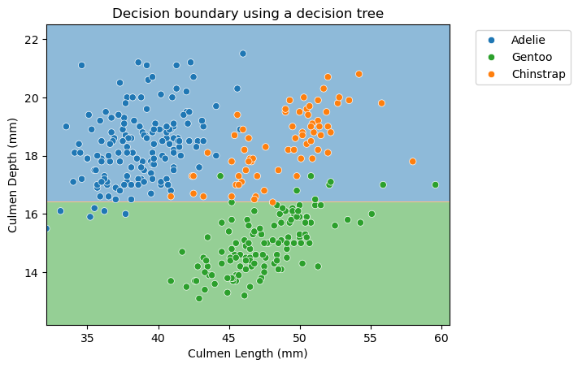

```python
DecisionBoundaryDisplay.from_estimator(
    tree,
    data_train,
    response_method="predict",
    cmap="tab10",
    norm=tab10_norm,
    alpha=0.5,
)
sns.scatterplot(
    data=df,
    x=culmen_columns[0],
    y=culmen_columns[1],
    hue=target_column,
    palette=palette,
)
plt.legend(bbox_to_anchor=(1.05, 1), loc="upper left")
_ = plt.title("Decision boundary using a decision tree")
# Frontière de décision utilisant un arbre de décision
```

Les partitions trouvées par l'algorithme séparent les données selon l'axe "Culmen Depth", en ignorant la caractéristique "Culmen Length". Cela met en évidence qu'un arbre de décision n'utilise pas une combinaison de caractéristiques lors d'une seule division. Nous pouvons examiner plus en détail la structure de l'arbre.

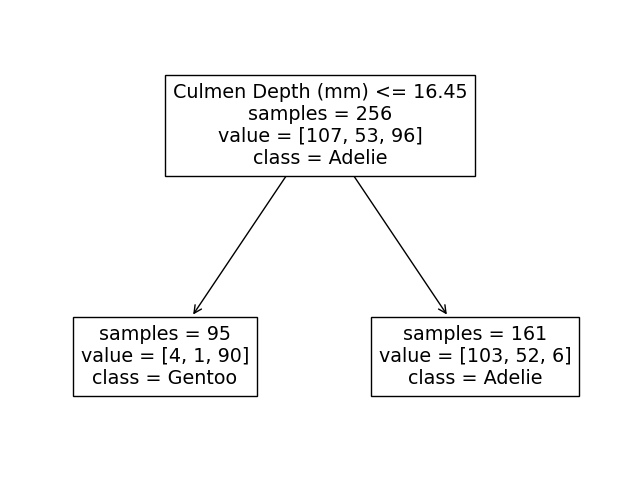

```python
from sklearn.tree import plot_tree

_, ax = plt.subplots(figsize=(8, 6))
_ = plot_tree(
    tree,
    feature_names=culmen_columns,
    class_names=tree.classes_.tolist(),
    impurity=False,
    ax=ax,
)
```

Nous utilisons la fonction fig, ax = plt.subplots(figsize=(8, 6)) pour créer une figure et un axe avec une taille spécifique. Ensuite, nous pouvons passer l'axe à la fonction sklearn.tree.plot_tree afin que le dessin se fasse dans cet axe.

Nous voyons que la division a été effectuée sur la caractéristique culmen depth. Le dataset original a été subdivisé en 2 ensembles en fonction de la profondeur du bec (inférieure ou supérieure à 16,45 mm).

Cette partition du dataset minimise la diversité des classes dans chaque sous-partition. Cette mesure est également connue sous le nom de critère, et c'est un paramètre configurable.

Si nous examinons de plus près la partition, nous voyons que les échantillons supérieurs à 16,45 mm appartiennent principalement à la classe "Adelie". En regardant les valeurs, nous observons en effet 103 individus "Adelie" dans cet espace. Nous comptons également 52 échantillons "Chinstrap" et 6 échantillons "Gentoo". Nous pouvons faire une interprétation similaire pour la partition définie par un seuil inférieur à 16,45 mm. Dans ce cas, la classe la plus représentée est l'espèce "Gentoo".

```python
test_penguin_1 = pd.DataFrame(
    {"Culmen Length (mm)": [0], "Culmen Depth (mm)": [15]}
)
tree.predict(test_penguin_1)
```

```
array(['Gentoo'], dtype=object)
```

La classe prédite est "Gentoo". Nous pouvons maintenant vérifier ce qui se passe si nous passons une profondeur du bec supérieure au seuil.

```python
test_penguin_2 = pd.DataFrame(
    {"Culmen Length (mm)": [0], "Culmen Depth (mm)": [17]}
)
tree.predict(test_penguin_2)
```

```
array(['Adelie'], dtype=object)
```

Dans ce cas, l'arbre prédit l'espèce "Adelie".

Ainsi, nous pouvons conclure qu'un classificateur par arbre de décision prédit la classe la plus représentée dans une partition.

Pendant l'entraînement, nous avons un décompte des échantillons dans chaque partition, et nous pouvons également calculer la probabilité d'appartenir à une classe spécifique au sein de cette partition.

```python
y_pred_proba = tree.predict_proba(test_penguin_2)
y_proba_class_0 = pd.Series(y_pred_proba[0], index=tree.classes_)
```

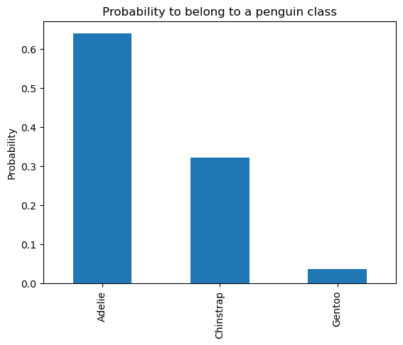

```python
y_proba_class_0.plot.bar()
plt.ylabel("Probability")
_ = plt.title("Probability to belong to a penguin class")
```

Nous pouvons également calculer les différentes probabilités manuellement directement à partir de la structure de l'arbre

```python
adelie_proba = 103 / 161
chinstrap_proba = 52 / 161
gentoo_proba = 6 / 161
print(
    "Probabilities for the different classes:\n"
    f"Adelie: {adelie_proba:.3f}\n"
    f"Chinstrap: {chinstrap_proba:.3f}\n"
    f"Gentoo: {gentoo_proba:.3f}\n"
)
```

```
Probabilities for the different classes:
Adelie: 0.640
Chinstrap: 0.323
Gentoo: 0.037
```

Il est également important de noter que la longueur du bec (culmen length) a été ignorée pour le moment. Cela signifie que, quelle que soit sa valeur, elle n'est pas utilisée pendant la prédiction.

```python
test_penguin_3 = pd.DataFrame(
    {"Culmen Length (mm)": [10_000], "Culmen Depth (mm)": [17]}
)
tree.predict_proba(test_penguin_3)
```

```
array([[0.63975155, 0.32298137, 0.03726708]])
```

Revenons à notre problème de classification : la division trouvée avec une profondeur maximale de 1 n'est pas suffisamment puissante pour séparer les trois espèces, et la précision du modèle est faible par rapport au modèle linéaire.

```python
tree.fit(data_train, target_train)
test_score = tree.score(data_test, target_test)
print(f"Accuracy of the DecisionTreeClassifier: {test_score:.2f}")
```

```
Accuracy of the DecisionTreeClassifier: 0.78
```

En effet, ce n'est pas une surprise. Nous avons vu précédemment qu'une seule caractéristique n'est pas capable de séparer les trois espèces : le modèle sous-ajuste (underfit). Cependant, à partir de l'analyse précédente, nous avons vu qu'en utilisant les deux caractéristiques, nous devrions être en mesure d'obtenir des résultats assez bons.

Dans l'exercice suivant, vous augmenterez la profondeur de l'arbre pour avoir une intuition de la manière dont un tel paramètre affecte la partition de l'espace.